# Recurrent Network Architectures

## Model 1

For the first model I will use a LSTM recurent neural network. The output of the embeding layer will be 50 and the vector inside the recurent network will be of size 128.

```python
from keras.models import Sequential
from keras.layers import Dense
from keras.layers import LSTM
from keras.layers import Embedding

EMBED_SIZE = 50

embedding_layer = Embedding(len(word_index) + 1,
                            EMBED_SIZE,
                            input_length=MAX_LEN)

rnn = Sequential()
rnn.add(embedding_layer)
rnn.add(LSTM(128,dropout=0.4, recurrent_dropout=0.4))
rnn.add(Dense(1, activation='sigmoid'))
rnn.compile(loss='binary_crossentropy',
              optimizer='rmsprop',
              metrics=['accuracy'])
print(rnn.summary())
```

```
Model: "sequential_1"
_________________________________________________________________
Layer (type)                 Output Shape              Param #
=================================================================
embedding_1 (Embedding)      (None, 15, 50)            4435150
_________________________________________________________________
lstm_1 (LSTM)                (None, 128)               91648
_________________________________________________________________
dense_1 (Dense)              (None, 1)                 129
=================================================================
Total params: 4,526,927
Trainable params: 4,526,927
Non-trainable params: 0
_________________________________________________________________
None
```

```python
rnn.fit(X_train, y_train,
        validation_data=(X_test, y_test),
        epochs=5, batch_size=64)
```

```
Train on 115200 samples, validate on 28800 samples
```

```
<keras.callbacks.callbacks.History at 0x22f58a902c8>
```

```python
from sklearn import metrics as mt
from sklearn.metrics import roc_curve
from sklearn.metrics import auc
import seaborn as sns
import matplotlib.pyplot as plt
%matplotlib inline

def summarize_net(net, X_test, y_test, title_text=''):
    yhat = net.predict(X_test).round()
    acc = mt.accuracy_score(y_test,yhat)
    cm = mt.confusion_matrix(y_test,yhat)
    cm = cm/np.sum(cm,axis=1)[:,np.newaxis]
    cm = pd.DataFrame(cm , index = ['0','1'] , columns = ['0','1'])

    plt.figure(figsize = (12,6))
    plt.subplot(1, 2, 1)
    sns.heatmap(cm,cmap= "coolwarm", linecolor = 'black' ,
                linewidth = 1 , annot = True, fmt='.2f')
    plt.title(title_text+'{:.4f}'.format(acc))

    fpr, tpr, thresholds = roc_curve(y_test, yhat)
    auc_keras = auc(fpr, tpr)

    plt.subplot(1, 2, 2)
    plt.plot([0, 1], [0, 1], 'k--')
    plt.plot(fpr, tpr, label=' (area = {:.3f})'.format(auc_keras))
    plt.xlabel('False positive rate')
    plt.ylabel('True positive rate')
    plt.title('ROC curve')
    plt.legend(loc='best')
    plt.show()
```

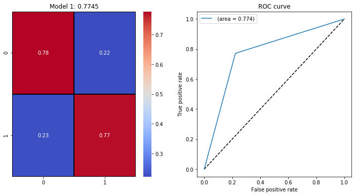

```python
summarize_net(rnn, X_test, y_test, title_text='Model 1: ')
```

## Model 2

In this model I will use the already trained embedding layer – GloVe. Also, now I will use GRU and a vector size of 256 in the recurrent process.

```python
# Code was tooken from the class notebook:

embeddings_index = {}
f = open('PA02Files/glove.6B.50d.txt', encoding="utf8")
# save key/array pairs of the embeddings
#  the key of the dictionary is the word, the array is the embedding
for line in f:
    values = line.split()
    word = values[0]
    coefs = np.asarray(values[1:], dtype='float32')
    embeddings_index[word] = coefs
f.close()

print('Found %s word vectors.' % len(embeddings_index))

# now fill in the matrix, using the ordering from the
#  keras word tokenizer from before
embedding_matrix = np.zeros((len(word_index) + 1, EMBED_SIZE))
for word, i in word_index.items():
    embedding_vector = embeddings_index.get(word)
    if embedding_vector is not None:
        # words not found in embedding index will be all-zeros.
        embedding_matrix[i] = embedding_vector

print(embedding_matrix.shape)
```

```
Found 400000 word vectors.
(88703, 50)
```

```python
from keras.layers import GRU

embedding_layer = Embedding(len(word_index) + 1,
                            EMBED_SIZE,
                            weights=[embedding_matrix],
                            input_length=MAX_LEN,
                            trainable=False)

rnn2 = Sequential()
rnn2.add(embedding_layer)
rnn2.add(GRU(256,dropout=0.3, recurrent_dropout=0.3))
rnn2.add(Dense(1, activation='sigmoid'))
rnn2.compile(loss='binary_crossentropy',
              optimizer='rmsprop',
              metrics=['accuracy'])
print(rnn2.summary())
```

```
Model: "sequential_11"
_________________________________________________________________
Layer (type)                 Output Shape              Param #
=================================================================
embedding_11 (Embedding)     (None, 15, 50)            4435150
_________________________________________________________________
gru_5 (GRU)                  (None, 256)               235776
_________________________________________________________________
dense_8 (Dense)              (None, 1)                 257
=================================================================
Total params: 4,671,183
Trainable params: 236,033
Non-trainable params: 4,435,150
_________________________________________________________________
None
```

```python
rnn2.fit(X_train, y_train,
        validation_data=(X_test, y_test),
        epochs=5, batch_size=64)
```

```
Train on 115200 samples, validate on 28800 samples
```

```
<keras.callbacks.callbacks.History at 0x1c2ae617c88>
```

```python
# train more 10 epochs

rnn2.fit(X_train, y_train,
        validation_data=(X_test, y_test),
        epochs=10, batch_size=64)
```

```
Train on 115200 samples, validate on 28800 samples
```

```
<keras.callbacks.callbacks.History at 0x1c2b62e7648>
```

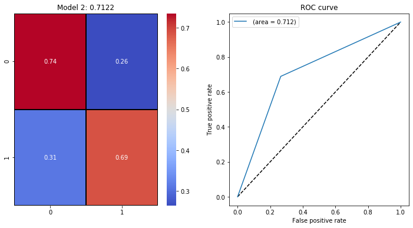

```python
summarize_net(rnn2, X_test, y_test, title_text='Model 2: ')
```

## Comparing between Model 1 and Model 2

From the accuracy of the two models we can see that the first model, where I used LSTM with no any pre-processing (77.45%), scored higher than the second model where I used the GRU and the GloVe embedding layer (71.22%). We can also see that the area under the ROC curve of the first model is larger than this of the second model. Even tough I did not accomplish my goal of reaching the 90% accuracy like I said at the beginning, with the first model I reached higher accuracy than I had before, in the data structures class. However, the second model scored lower than before.

```python
# return a bool if we 90% confident to reject the null hypothesis
def get_chi_square(net1,net2,X_test,y_test):
    yhat1 = net1.predict(X_test).round().reshape(y_test.shape)
    yhat2 = net2.predict(X_test).round().reshape(y_test.shape)
    yhat1_acc = yhat1 == y_test
    yhat2_acc = yhat2 == y_test
    b = 0 # 1 correct, 2 not
    c = 0 # 2 correct, 1 not

    for i in range(len(y_test)):
        if yhat1_acc[i] and not yhat2_acc[i]:
            b += 1
        elif not yhat1_acc[i] and yhat2_acc[i]:
            c += 1

    chi_square = (abs(b-c)-1)**2/(b+c)
    return chi_square > 2.706
```

```python
if get_chi_square(rnn,rnn2, X_test, y_test):
    print('Model 1 is different than Model 2 with 90% confidence')
else:
    print('We can not assume that Model 2 is different than Model 1')
```

```
Model 1 is different than Model 2 with 90% confidence
```

Since that two model are different from one another with a confidence of 90%, I can say that the first model is better than the second one.

## Adding a second recurrent chain to the RNN

Since the first model performed better, I will add the layer to this model

```python
embedding_layer = Embedding(len(word_index) + 1,
                            EMBED_SIZE,
                            input_length=MAX_LEN)

rnn_2lay = Sequential()
rnn_2lay.add(embedding_layer)
rnn_2lay.add(LSTM(128,dropout=0.4,
                  recurrent_dropout=0.4,
                  return_sequences=True))
rnn_2lay.add(LSTM(64,dropout=0.2, recurrent_dropout=0.2))
rnn_2lay.add(Dense(1, activation='sigmoid'))
rnn_2lay.compile(loss='binary_crossentropy',
              optimizer='rmsprop',
              metrics=['accuracy'])
print(rnn_2lay.summary())
```

```
Model: "sequential_15"
_________________________________________________________________
Layer (type)                 Output Shape              Param #
=================================================================
embedding_15 (Embedding)     (None, 15, 50)            4435150
_________________________________________________________________
lstm_10 (LSTM)               (None, 15, 128)           91648
_________________________________________________________________
lstm_11 (LSTM)               (None, 64)                49408
_________________________________________________________________
dense_10 (Dense)             (None, 1)                 65
=================================================================
Total params: 4,576,271
Trainable params: 4,576,271
Non-trainable params: 0
_________________________________________________________________
None
```

```python
rnn_2lay.fit(X_train, y_train,
        validation_data=(X_test, y_test),
        epochs=5, batch_size=64)
```

```
Train on 115200 samples, validate on 28800 samples
```

```
<keras.callbacks.callbacks.History at 0x1c2beeb9f48>
```

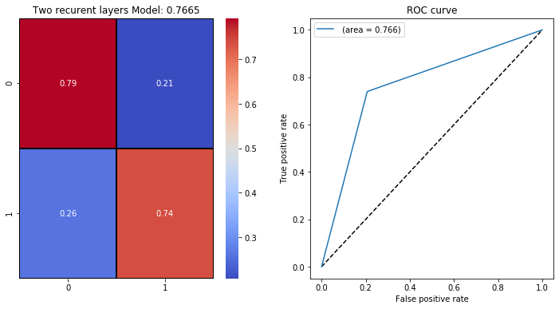

```python
summarize_net(rnn_2lay, X_test, y_test, title_text='Two recurent layers Model: ')
```

```python
if get_chi_square(rnn,rnn_2lay, X_test, y_test):
    print('Model 1 is different than the 2 recurent layer model with 90% confidence')
else:
    print('We can not assume that 2 recurent layer model is different than Model 1')
```

```
Model 1 is different than the 2 recurent layer model with 90% confidence
```

## Testing - unfiltered twits

Trying using the twits as they are with no any clearing of the text, leaving the stop words and the tagget users:

```python
tok2 = Tokenizer()
tok2.fit_on_texts(df_clear.text)
sequences = tok2.texts_to_sequences(df_clear.text)

word_index2 = tok2.word_index
top_words = len(word_index2)
print('Found %s unique words.' % (len(word_index2)))
```

```
Found 128084 unique words.
```

```python
MAX_LEN = 20
X = pad_sequences(sequences, maxlen=MAX_LEN)
y = np.array(df_clear.target)
print('data',X.shape)
print('target',y.shape)
print('positive twits:',np.sum(y))
print('negative twits:',y.shape[0]-np.sum(y))

X_train, X_test, y_train, y_test = train_test_split(X, y,
                                test_size=0.20, random_state=23, stratify=y)

print('X_train shape:',X_train.shape)
print('X_test shape:',X_test.shape)
print('y_train shape:',y_train.shape)
print('y_test shape:',y_test.shape)
```

```
data (144000, 20)
target (144000,)
positive twits: 72000
negative twits: 72000
X_train shape: (115200, 20)
X_test shape: (28800, 20)
y_train shape: (115200,)
y_test shape: (28800,)
```

```python
EMBED_SIZE = 50

embedding_layer = Embedding(len(word_index2) + 1,
                            EMBED_SIZE,
                            input_length=MAX_LEN)

rnn_test = Sequential()
rnn_test.add(embedding_layer)
rnn_test.add(LSTM(128,dropout=0.4, recurrent_dropout=0.4))
rnn_test.add(Dense(1, activation='sigmoid'))
rnn_test.compile(loss='binary_crossentropy',
              optimizer='rmsprop',
              metrics=['accuracy'])
print(rnn_test.summary())
```

```
Model: "sequential_17"
_________________________________________________________________
Layer (type)                 Output Shape              Param #
=================================================================
embedding_17 (Embedding)     (None, 20, 50)            6404250
_________________________________________________________________
lstm_13 (LSTM)               (None, 128)               91648
_________________________________________________________________
dense_12 (Dense)             (None, 1)                 129
=================================================================
Total params: 6,496,027
Trainable params: 6,496,027
Non-trainable params: 0
_________________________________________________________________
None
```

```python
rnn_test.fit(X_train, y_train,
        validation_data=(X_test, y_test),
        epochs=3, batch_size=64)
```

```
Train on 115200 samples, validate on 28800 samples
```

```
<keras.callbacks.callbacks.History at 0x1c2cc066508>
```

```python
rnn_test.fit(X_train, y_train,
        validation_data=(X_test, y_test),
        epochs=1, batch_size=64)
```

```
Train on 115200 samples, validate on 28800 samples
```

```
<keras.callbacks.callbacks.History at 0x1c2cb37be48>
```

```python
rnn_test.fit(X_train, y_train,
        validation_data=(X_test, y_test),
        epochs=1, batch_size=64)
```

```
Train on 115200 samples, validate on 28800 samples
```

```
<keras.callbacks.callbacks.History at 0x1c2cb64e8c8>
```

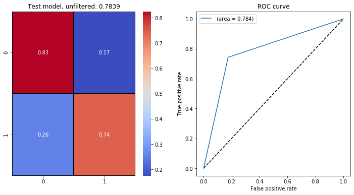

```python
summarize_net(rnn_test, X_test, y_test, title_text='Test model, unfiltered: ')
```

## Exceptional Work

Use t-SNE to visualize the word embeddings of a subset of words in your vocabulary

```python
# to get all the layers' weights
weights = []
for layer in rnn.layers:
    weights.append(layer.get_weights())

weights[0][0].shape
```

```
(88703, 50)
```

```python
# showing sample words form the vocabulary

import random

# tok.word_index is a dict with all the vocabulary
# key is the word, value is the numeric value of it

vals = list(tok.word_index.values())
keys = list(tok.word_index.keys())

to_show = [random.randint(0,88703) for i in range(20)]

for i in to_show:
    print(vals[i],':',keys[i])
```

```
77868 : cruces
11326 : dramas
12643 : hereby
35067 : schreibwerkstatt
83636 : fury
71798 : alix
77524 : yardno
27712 : drunkquot
20604 : pmquot
14937 : macys
26552 : trumping
45825 : oooppps
54122 : httpbitlyhuosf
62204 : uxlondon
85353 : morrowphysically
42332 : quotcollege
61632 : sency
75614 : pantries
59158 : earlymorning
51722 : chancei
```

```python
from sklearn.manifold import TSNE

#reduce to 2D, just 300 words
rand = random.randint(0,85703)
X_embedded = TSNE(n_components=2).fit_transform(weights[0][0][rand:rand+300])
X_embedded.shape
```

```
(300, 2)
```

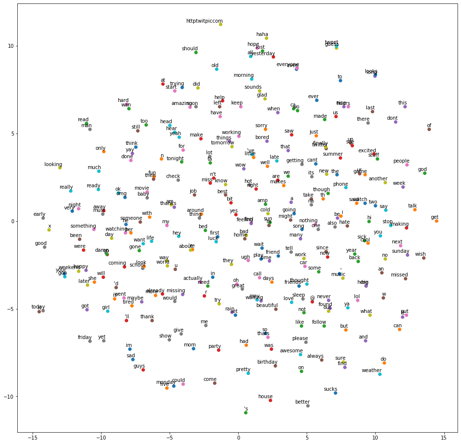

```python
labels = []

for word in tok.word_index:
    labels.append(word)


x = []
y = []
for value in X_embedded:
    x.append(value[0])
    y.append(value[1])

plt.figure(figsize=(16, 16))
for i in range(len(x)):
    plt.scatter(x[i],y[i])
    plt.annotate(labels[i],
                     xy=(x[i], y[i]),
                     xytext=(5, 2),
                     textcoords='offset points',
                     ha='right',
                     va='bottom')
plt.show()
```